# 2 Tipos de datos

Una de las principales funciones de R es el manejo y análisis de una diversidad de datos. Para ello R los clasifica en tres principales grupos:

- Numéricos
- Lógicos
- Caracteres

## 2.1 Datos numéricos

Existen dos principales tipos de datos nuéricos: los números **enteros** o *integer* con valores positivos o negativos y los números **decimales** o *numeric* con valores positivos o negativos:

```r
4


-36


7.65


-5.47
```

Con los valores numéricos es posible realizar todo tipo de operaciones algebraicas:

```r
3+4
```

```
## [1] 7
```

```r
100-60
```

```
## [1] 40
```

```r
9.7*6
```

```
## [1] 58.2
```

```r
450/9
```

```
## [1] 50
```

```r
2^5
```

```
## [1] 32
```

```r
sqrt(121)
```

```
## [1] 11
```

```r
log10(100)
```

```
## [1] 2
```

## 2.2 Datos lógicos

Son datos que toman el valor de una variable dicotómica, es decir con dos categorías: verdadero *TRUE* (T) o falso *FALSE* (F). También se le conoce como valores *boleanos* o *logical*. Siempre se esciben con letras MAYUSCULAS

```r
TRUE
```

```
## [1] TRUE
```

```r
T
```

```
## [1] TRUE
```

```r
FALSE
```

```
## [1] FALSE
```

```r
F
```

```
## [1] FALSE
```

## 2.3 Caracteres

Los caracteres o *character* representan texto que comprende letras, palabras, frases o enunciados. Para ingresar un caracter es importante inseratrlo entre comillas:

```r
"W"
```

```
## [1] "W"
```

```r
"Variable"
```

```
## [1] "Variable"
```

```r
"Linea de codigo"
```

```
## [1] "Linea de codigo"
```

```r
"Esta linea de codigo se escribe entre comillas"
```

```
## [1] "Esta linea de codigo se escribe entre comillas"
```

Una manera de verificar el tipo o la clase de los datos es empleando la función o comando `class()`

```r
##La función class() para conocer el tipo de datos
class(3)
```

```
## [1] "numeric"
```

```r
class(-5.4)
```

```
## [1] "numeric"
```

```r
class(TRUE)
```

```
## [1] "logical"
```

```r
class(FALSE)
```

```
## [1] "logical"
```

```r
class("w")
```

```
## [1] "character"
```

```r
class("Una cadena de caracteres")
```

```
## [1] "character"
```

Un caso especial son los datos *faltantes*, a los cuales se les asigna el nombre **NA**.

# 3 Variables

Una variable es un espacio en la memoria de la computadora en donde se almacenan datos de cualquier tipo. Para crear o declarar una variable se utilizan los siguientes signos de asignación:

```r
numero <- 2
texto <- "Pablito clavo un clavito"
logico <- TRUE

numero = -1
texto = "Tres tristes tigres"
logico = FALSE
```

Las variables que declares se almacenan en el cuadrante 3 que corresponde al **Entorno de variables**.  
Con las variables numéricas es posible realizar las operaciones algebraicas previamente mencionadas:

```r
numero_1 <- 203
numero_2 <- 64
```

Una vez que declares una variable, es posible que realices operaciones algebraicas entre ellas. Además, es posible que verifiques el tipo de dato que almacena la variable y las concatenes:

```r
galon <- 3.785
litros <- 5
conv <- litros/galon

class(galon)
```

```
## [1] "numeric"
```

```r
class(litros)
```

```
## [1] "numeric"
```

```r
class(conv)
```

```
## [1] "numeric"
```

> **Ejercicio 1**  
> Visita la siguiente liga y resuelve el [ejercicio](https://rchavezdominguez.shinyapps.io/Quiz_1/)

# 4 Datos complejos

En R puedes manejar estructuras de datos más complejas. Esto es útil al momento de analizar tablas, matrices o listas de datos. Las principales estructures complejas de datos son:

- Vectores
- Matrices
- Data frames
- Listas

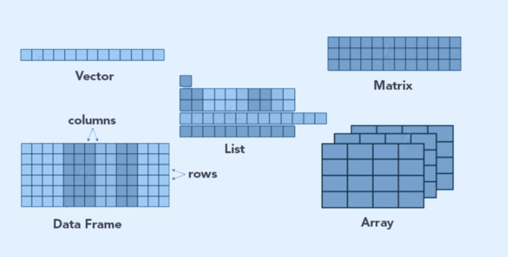

Tipo y estructuras de datos en R. Tomada de https://www.analytixlabs.co.in/blog/r-programming-language-basics/